# 第一章 初识R语言

周 静

# 目录

- 初识R语言
- 安装R语言
- 获取R帮助文档
- 学习使用Rmarkdown

# 初识R语言：R语言的热门程度

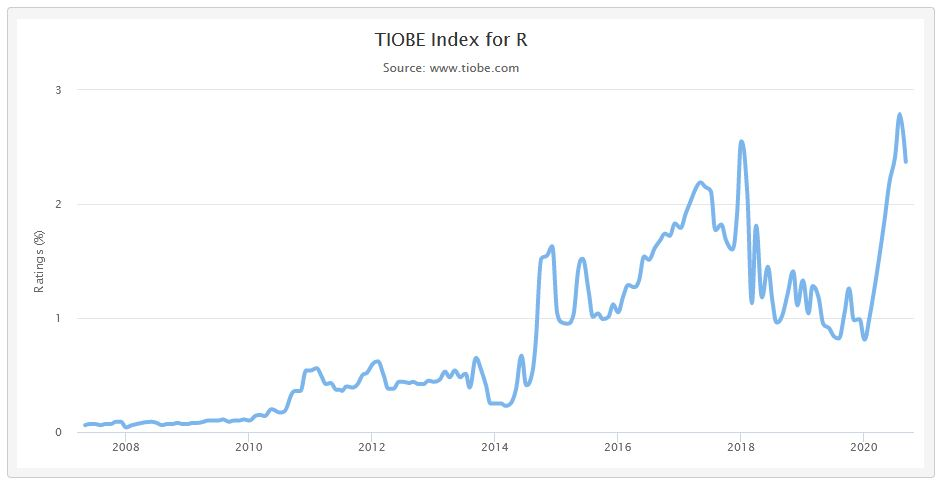

# 初识R语言：R语言大会

[figure not shown]

# 初识R语言：R语言相关工作

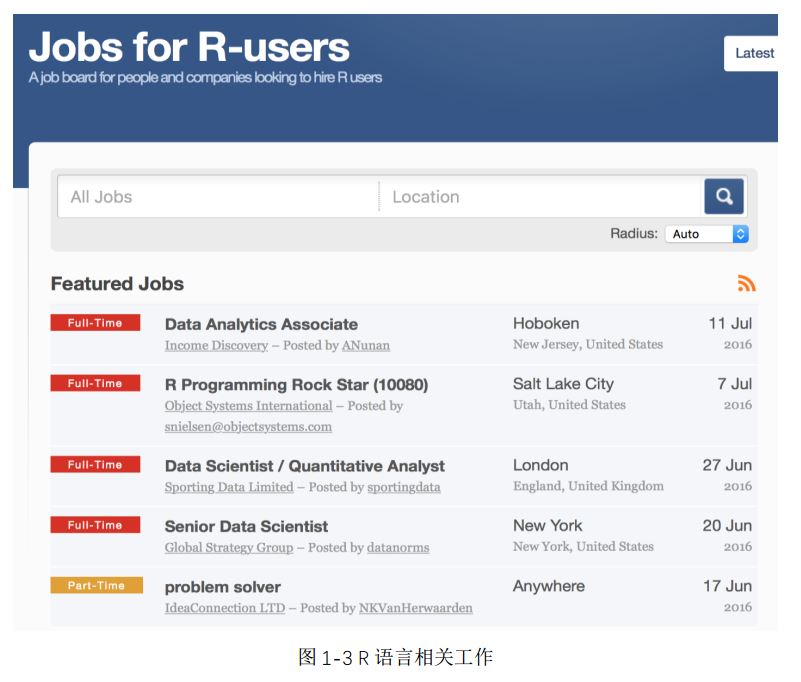

# R语言是什么

- R 是一个有着强大统计分析功能及作图功能的软件系统，下图是它的操作界面

[figure not shown]

# R语言是什么

- 说到 R 语言的发展历程，还要先从另一门语言S谈起。 S语言是由AT&T贝尔实验室 John Chambers 等人开发的一种用来统计编程的语言。 它目前有两种实现版本： 一种是现在由 TIBCO 经营的商业软件 S-plus； 另一种就是免费开源的R语言。
- 1992 年，Auckland 大学的 Robert Gentleman 和 Ross Ihaka 为了能够更有效 地开展大学里的统计入门课程的教学， 他们决定引入 S 语言来开发一套软件。 1994 年该软件最初版本基本成型， 这就是后来我们用到的 R 的雏形。

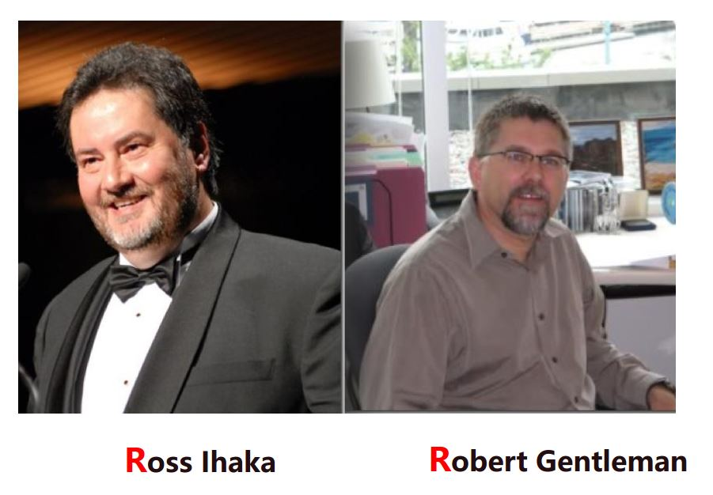

# 为什么使用R语言

- 物美价廉——作图颜值高， 且完全免费

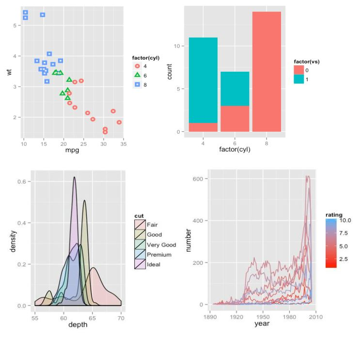

[figure not shown]

# 为什么使用R语言

- 兼收并蓄——算法覆盖广， 扩展易

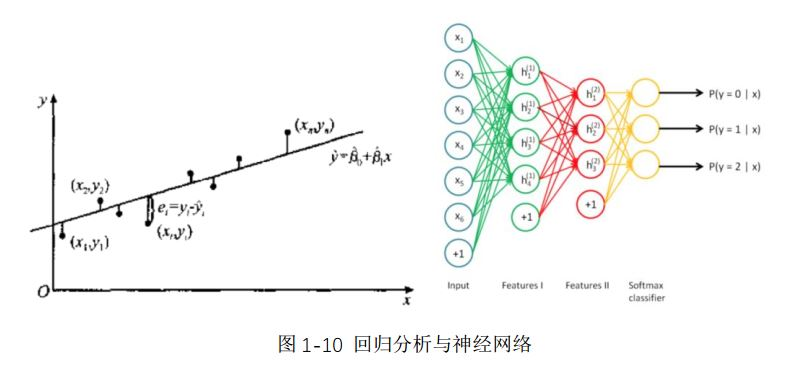

[figure not shown]

# R语言的其他技能

- 用R语言给自己画肖像，用R语言开发游戏

[figure not shown]

[figure not shown]

- 2019年7月31日，Rstudio公司的首席科学家Hadley Wickham获得了当年的考普斯会长奖（COPSS Presidents’ Award），以表彰他在统计应用领域做出的卓越贡献。

# R的获取和安装

- Step 1: 登陆 R 语言官方网站 https://www.r-project.org， 点击 download R。
- Step 2: 在弹出的镜像（Mirrors） 页面上选择合适的镜像入口， 如果你在中国， 就直接选择 China 下离你近的一个镜像即可。
- Step 3: 选择镜像后就会跳转到下载页面， 此时即可根据自己电脑的操作系统酌 情选择啦！

# R的升级版武器：Rstudio介绍

- 如果你嫌弃R的界面太丑怎么办？接下来介绍他的升级版武器：Rstudio编辑器！

[figure not shown]

# 什么是Rstudio

- RStudio是一个R语言的集成开发环境（IDE）。所谓集成开发环境，就是把你做开发工作所需要的代码编辑器、编译器、调试器等工具都集成在一个界面环境下，方便同时开工。接下来，我们通过一个简单的示例图来详细了解下RStudio各个模块的定义以及使用流程

[figure not shown]

# R包的获取与安装

- 什么是R包，为什么要安装他？
  - 所谓 R 包， 就是一个把 R 函数、 数据、 预编译代码以一种定义完善的格式组成在一起的集合
  - R在安装时会自带一系列默认包（包括base， datasets， stats， methods，graphics等包）,它们提供了很多功能丰富的函数与数据，大家可以自行调出学习，命令search()可以告诉你工作空间里已有哪些包可被直接使用。当然，如果需要装备更多、 更厉害的拓展技能，就需要安装新包来实现了！

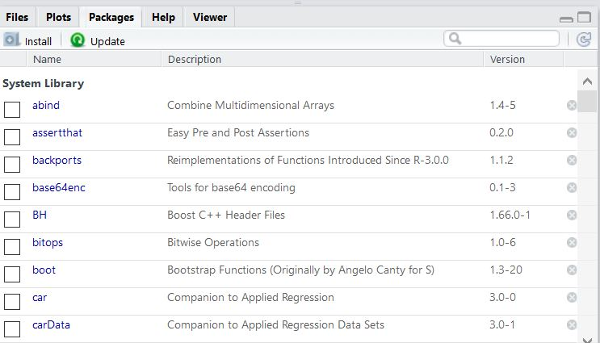

# 怎样安装R包

- 一般的安装做法有两种：一种是通过CRAN服务器安装；另一种是从Github上下载安装，可做为第一种的补充。
- 第一种方法最常用。在RStudio中可以有两种方法实现： 一种是直接通过命令装包： `install.packages (“package_name”)`
- 另一种是选中如下图所示的右 下方的界面中的Packages后， 点击Install， 就会弹出如下图所示的方框， 直接 在其中输入包的名称就可以了

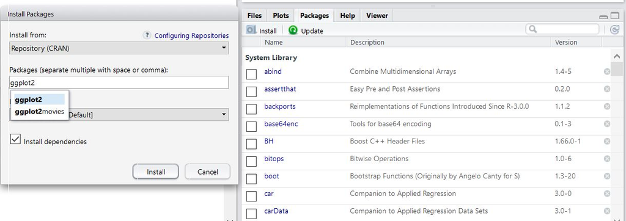

# R包的调用

- 安装好就能直接用了吗？
- 安装好了包， 只是把它放在本地硬盘里，用时需要打开才能调用它的函数。 打开的方式很简单， 选用以下函数之一即可完成。
- `library(“package_name”)`
- `require(“package_name”)`

# 获取R帮助文档

- 在Rstudio里查看帮助，在 R 中求助， 最直接的入口就是 RStudio 右下角的 Help

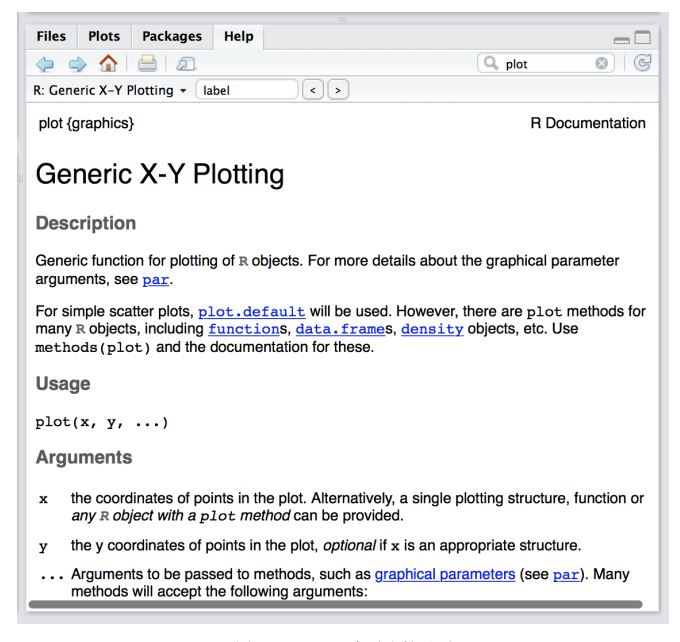

# 获取R帮助的其他方法

- 使用 demo()函数
  - 如果想看某个函数的使用样例，可以尝试使用demo()函数，它里面也包含一些函数示范小案例， 输入 demo()查看已经加载进内存的包里有例子的函数列表， 输入`demo(“function_name”)`就可以执行某个具体函数的例子了。
- 参考 Quick-R 网站
  - 如果想看某些统计方法及数据操作的样例，网站 Quick-R （http://www.statmethods.net/index.html） 是个不错的选择， 内容很丰富，包含了大量按主题划分的包含完整代码的示范，极易上手。另外，每一篇文章里包含了 很多相关主题的超链接，让你在学习中有不懂就直接跳到相关的文档页面，十分方便。
- 学会使用搜索引擎
  - 以谷歌为例， 它的搜索能力强大，定位精准，不仅可以完美捕捉 R 社区里 的相关解答，还会搜寻出其他各类形式、 各种来源的辅助学习材料，让我们有机 会深入了解问题的来龙去脉，而不仅仅是获得一个答案。
- 求助于开源社区，论坛
  - COS中文论坛
  - StackOverflow：是一个专业的编程问答类网站，任何人都可以在上面提出各种 技术难题， 热心的专业人员会尝试解答，其他的观众可以通过点赞把优秀的回答 升到前面，这就让我们在查询时可以快速看到优质解答， 十分方便

# 什么是Rmarkdown

- R Markdown（简称 Rmd）， 从字面上看，就是一款基于 Markdown 的 R 语言 写作工具。 Markdown 是什么呢？首先 Markdown 一定是用来写作的，其次用 Markdown 写作的文本具有一定的格式。 简单来说， Markdown 是一款可以用文 本编辑器编写的标记语言。 通过一些简单的标记语言，就可以使文本具备一定的 排版格式，非常简单好用。
- 使用 Rmd 最大的好处就是：可以轻松地重现你的数据分析工作（make your work reproducible）。从原始数据的读入、清洗到最后的分析挖掘过程，每一步的 R code 都被清晰地记录在案。阅读你的 Rmd 结果的人可以完整地审查你的分析 思路和过程。
- **本学期提交的所有作业均用Rmarkdown完成**
- 先来个简单的，就是生成如下 HTML 文件里面包含代码和运行结果。复杂的大家可以自学。

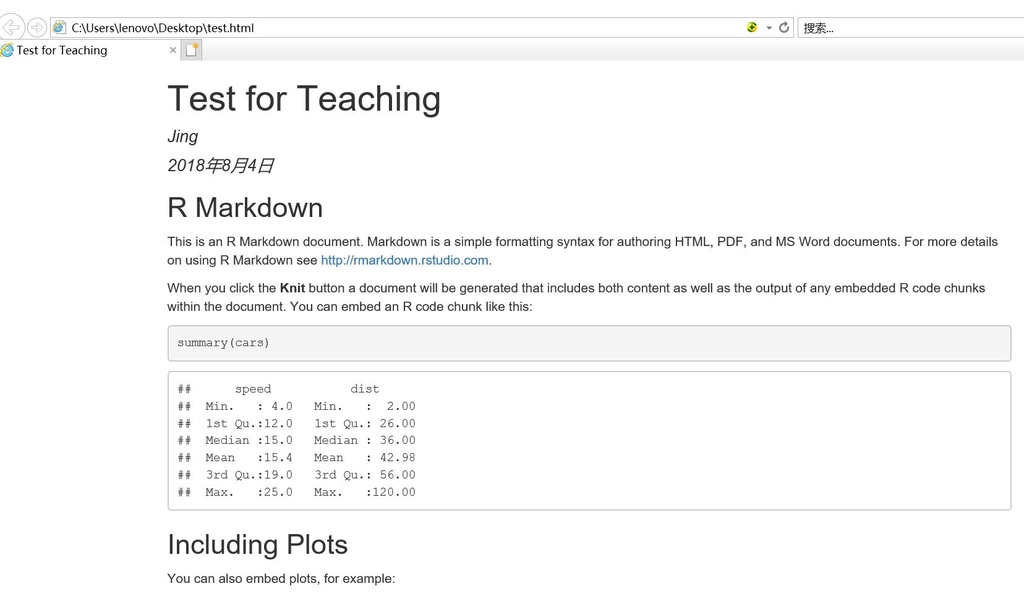

# 撰写Rmarkdown的简要步骤

- Step1：打开你的 Rstudio，左上角新建一个 R Markdown

[figure not shown]

# 撰写Rmarkdown的简要步骤

- Step2：点击之后会跳出一个对话框，命名一下文件&作者，选择输出的格式，就可以了

[figure not shown]

# 撰写Rmarkdown的简要步骤

- Step3：点击 OK 之后，长这样。 这时候会有个【Knit HTML】，点一下试试，就知道发生了什么。

[figure not shown]

# 请大家自学更复杂的RMD

- 谷歌和百度搜索你的各种问题
- http://rmarkdown.rstudio.com/lesson-1.html
- 在 Help 里面找到 R Markdown Cheat Sheet

[figure not shown]

# 优秀示例

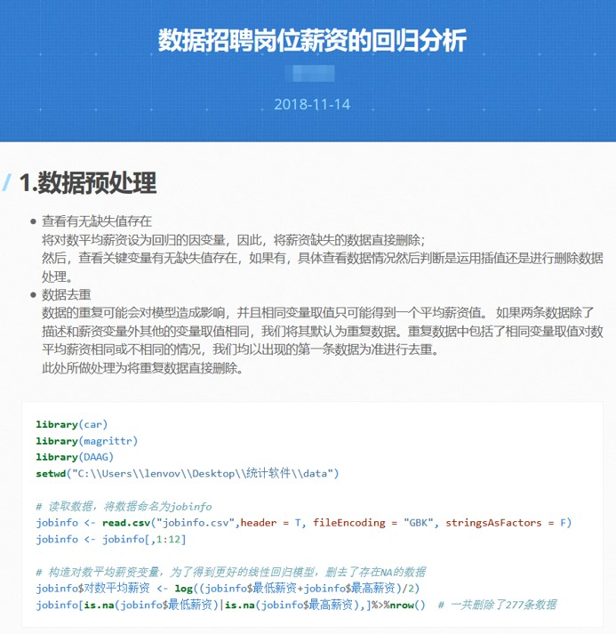

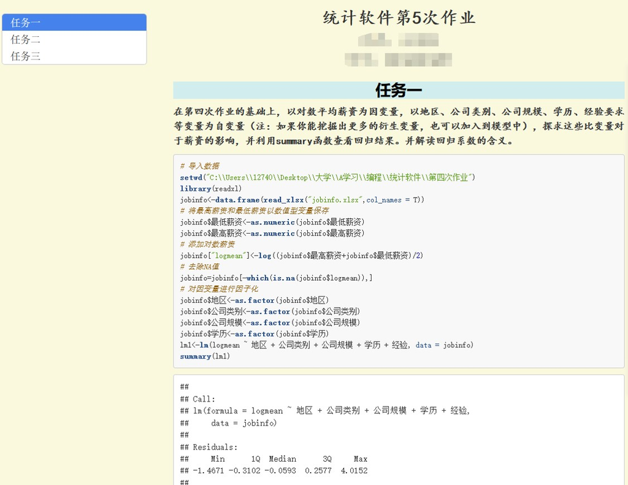

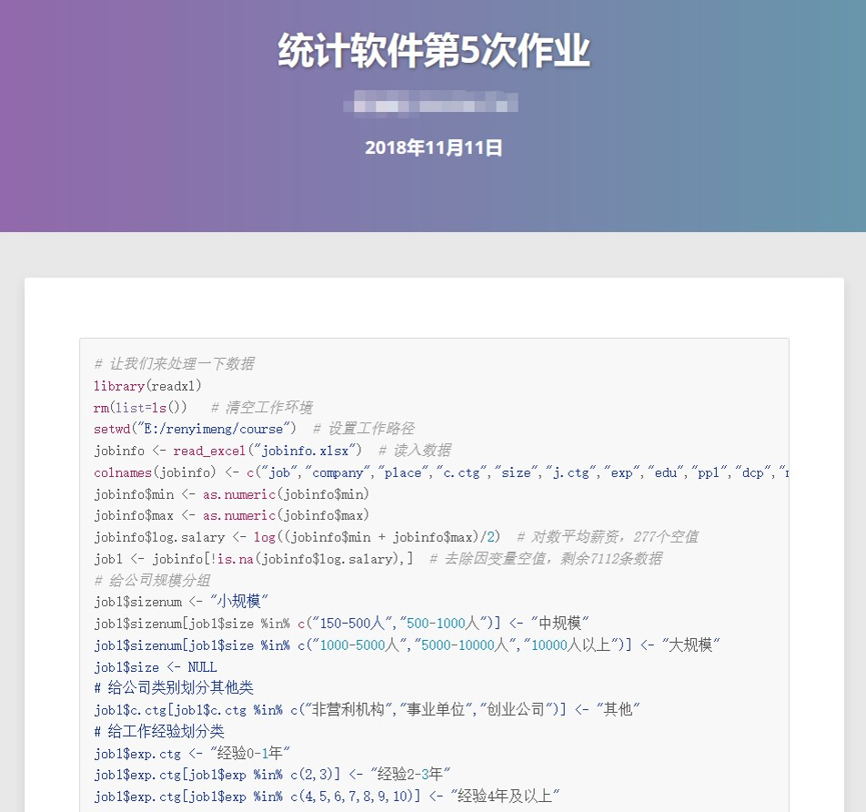